# (Loan Data from Prosper)

## by (Hatem Mohammed Kamal)

## Preliminary Wrangling

> a 113937 rows * 81 columns data about loans and the details related to borrower and the loan itself.

```python
# import all packages and set plots to be embedded inline
import numpy as np
import pandas as pd
import matplotlib.pyplot as plt
import seaborn as sns

%matplotlib inline
```

> Load in your dataset and describe its properties through the questions below. Try and motivate your exploration goals through this section.

```python
df = pd.read_csv('https://s3.amazonaws.com/udacity-hosted-downloads/ud651/prosperLoanData.csv')
df.head()
```

|  | ListingKey | ListingNumber | ListingCreationDate | CreditGrade | Term | LoanStatus | ClosedDate | BorrowerAPR | BorrowerRate | LenderYield | EstimatedEffectiveYield | EstimatedLoss | EstimatedReturn | ProsperRating (numeric) | ProsperRating (Alpha) | ProsperScore | ListingCategory (numeric) | BorrowerState | Occupation | EmploymentStatus | EmploymentStatusDuration | IsBorrowerHomeowner | CurrentlyInGroup | GroupKey | DateCreditPulled | CreditScoreRangeLower | CreditScoreRangeUpper | FirstRecordedCreditLine | CurrentCreditLines | … |
| --- | --- | --- | --- | --- | --- | --- | --- | --- | --- | --- | --- | --- | --- | --- | --- | --- | --- | --- | --- | --- | --- | --- | --- | --- | --- | --- | --- | --- | --- | --- |
| 0 | 1021339766868145413AB3B | 193129 | 2007-08-26 19:09:29.263000000 | C | 36 | Completed | 2009-08-14 00:00:00 | 0.16516 | 0.1580 | 0.1380 | NaN | NaN | NaN | NaN | NaN | NaN | 0 | CO | Other | Self-employed | 2.0 | True | True | NaN | 2007-08-26 18:41:46.780000000 | 640.0 | 659.0 | 2001-10-11 00:00:00 | 5.0 | … |
| 1 | 10273602499503308B223C1 | 1209647 | 2014-02-27 08:28:07.900000000 | NaN | 36 | Current | NaN | 0.12016 | 0.0920 | 0.0820 | 0.07960 | 0.0249 | 0.05470 | 6.0 | A | 7.0 | 2 | CO | Professional | Employed | 44.0 | False | False | NaN | 2014-02-27 08:28:14 | 680.0 | 699.0 | 1996-03-18 00:00:00 | 14.0 | … |
| 2 | 0EE9337825851032864889A | 81716 | 2007-01-05 15:00:47.090000000 | HR | 36 | Completed | 2009-12-17 00:00:00 | 0.28269 | 0.2750 | 0.2400 | NaN | NaN | NaN | NaN | NaN | NaN | 0 | GA | Other | Not available | NaN | False | True | 783C3371218786870A73D20 | 2007-01-02 14:09:10.060000000 | 480.0 | 499.0 | 2002-07-27 00:00:00 | NaN | … |
| 3 | 0EF5356002482715299901A | 658116 | 2012-10-22 11:02:35.010000000 | NaN | 36 | Current | NaN | 0.12528 | 0.0974 | 0.0874 | 0.08490 | 0.0249 | 0.06000 | 6.0 | A | 9.0 | 16 | GA | Skilled Labor | Employed | 113.0 | True | False | NaN | 2012-10-22 11:02:32 | 800.0 | 819.0 | 1983-02-28 00:00:00 | 5.0 | … |
| 4 | 0F023589499656230C5E3E2 | 909464 | 2013-09-14 18:38:39.097000000 | NaN | 36 | Current | NaN | 0.24614 | 0.2085 | 0.1985 | 0.18316 | 0.0925 | 0.09066 | 3.0 | D | 4.0 | 2 | MN | Executive | Employed | 44.0 | True | False | NaN | 2013-09-14 18:38:44 | 680.0 | 699.0 | 2004-02-20 00:00:00 | 19.0 | … |

5 rows × 81 columns

```python
# from the description of the data set i choosed the following variables
interest_df = df[['ListingKey', 'EmploymentStatusDuration', 'BorrowerAPR',
                  'StatedMonthlyIncome', 'ProsperRating (Alpha)', 'Term',
                  'LoanOriginalAmount', 'DebtToIncomeRatio', 'TotalTrades',
                  'IncomeRange']]
```

```python
# counting null values
null_vals = interest_df.isna().sum()
null_vals[null_vals>0].sort_values(ascending=False)
```

```
ProsperRating (Alpha)       29084
DebtToIncomeRatio            8554
EmploymentStatusDuration     7625
TotalTrades                  7544
BorrowerAPR                    25
dtype: int64
```

```python
# we will drop the missing rows
interest_df = interest_df[interest_df['ProsperRating (Alpha)'].isna()==False]
interest_df = interest_df[interest_df['DebtToIncomeRatio'].isna()==False]
interest_df = interest_df[interest_df['EmploymentStatusDuration'].isna()==False]
print(interest_df.shape)
null_vals = interest_df.isna().sum()
null_vals[null_vals>0].sort_values(ascending=False)
```

```
(77543, 10)
```

```
Series([], dtype: int64)
```

```python
# removing duplicated keys
interest_df.drop_duplicates(subset=['ListingKey'], inplace=True)
print(interest_df.ListingKey.duplicated().sum())
interest_df.shape
```

```
0
```

```
(76754, 10)
```

```python
interest_df.info()
```

```
<class 'pandas.core.frame.DataFrame'>
Int64Index: 76754 entries, 1 to 113936
Data columns (total 10 columns):
 #   Column                    Non-Null Count  Dtype
---  ------                    --------------  -----
 0   ListingKey                76754 non-null  object
 1   EmploymentStatusDuration  76754 non-null  float64
 2   BorrowerAPR               76754 non-null  float64
 3   StatedMonthlyIncome       76754 non-null  float64
 4   ProsperRating (Alpha)     76754 non-null  object
 5   Term                      76754 non-null  int64
 6   LoanOriginalAmount        76754 non-null  int64
 7   DebtToIncomeRatio         76754 non-null  float64
 8   TotalTrades               76754 non-null  float64
 9   IncomeRange               76754 non-null  object
dtypes: float64(5), int64(2), object(3)
memory usage: 6.4+ MB
```

### What is/are the main feature(s) of interest in your dataset?

> I want to know how prosper is connected other values in the dataset.

### What features in the dataset do you think will help support your investigation into your feature(s) of interest?

> EmploymentStatusDuration, BorrowerAPR, StatedMonthlyIncome, DebtToIncomeRatio, TotalTrades, IncomeRange.

## Univariate Exploration

> In this section, investigate distributions of individual variables. If you see unusual points or outliers, take a deeper look to clean things up and prepare yourself to look at relationships between variables.

```python
# 'Term', 'BorrowerAPR', 'ProsperRating (Alpha)', 'EmploymentStatus', 'IsBorrowerHomeowner', 'ListingCategory (numeric)', 'DebtToIncomeRatio'
```

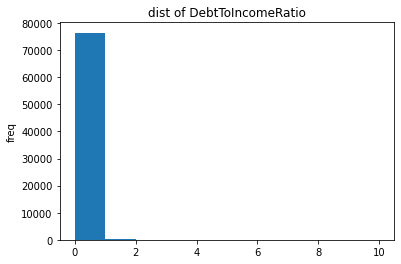

```python
# distribution of dept to income ratio
pins = np.arange(0, interest_df.DebtToIncomeRatio.max()+0.07, 1)
plt.hist(interest_df.DebtToIncomeRatio, bins=pins);
plt.title('dist of DebtToIncomeRatio');
plt.ylabel('freq');
```

Here we se that most of debt to income ratio is between 0-1, we will investigate it more in the following plot and outliers all the way to 10 we will see why in next plots.

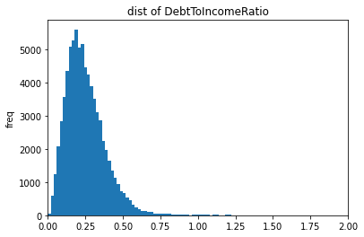

```python
pins = np.arange(0, interest_df.DebtToIncomeRatio.max()+0.02, 0.02)
plt.hist(interest_df.DebtToIncomeRatio, bins=pins);
plt.title('dist of DebtToIncomeRatio');
plt.ylabel('freq');
plt.xlim((0,2));
```

the plot follows a right skewd distrebution

```python
# choosing the color
base_color = sns.color_palette()[0]
```

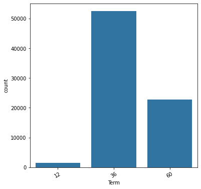

```python
# distribution of dept per state
plt.figure(figsize=(6,6))
sns.countplot(x=interest_df.Term, color=base_color);
plt.xticks(rotation=30)
```

most people choose the medium duaration which is 3 years

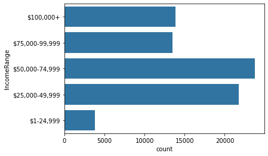

```python
# countplot for the number of borrowers for every range of income
order_income = ['$100,000+', '$75,000-99,999', '$50,000-74,999', '$25,000-49,999', '$1-24,999']
sns.countplot(y=interest_df.IncomeRange, color=base_color, order=order_income);
```

the number of people with medium income range in this sample data are taking loans more than the number people high range income, while the number of people who has low income is very low

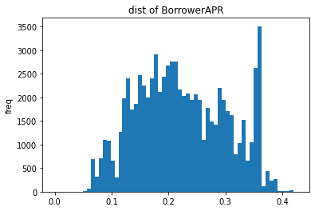

```python
pins = np.arange(0, interest_df.BorrowerAPR.max()+0.007, 0.007)
plt.hist(interest_df.BorrowerAPR, bins=pins);
plt.title('dist of BorrowerAPR');
plt.ylabel('freq');
```

the BorrowerAPR distribution looks like it has more than one distribution with a peak near 0.08 and another near 0.17, and a very big and strange peak at 0.35 , this will get more investgation.

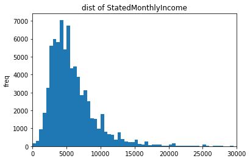

```python
pins = np.arange(0, interest_df.StatedMonthlyIncome.max()+500, 500)
plt.hist(interest_df.StatedMonthlyIncome, bins=pins);
plt.title('dist of StatedMonthlyIncome');
plt.xlim((0,30000))
plt.ylabel('freq');
```

a right skewed stated monthly income distribution

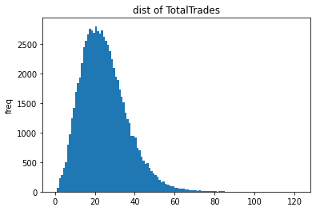

```python
pins = np.arange(0, interest_df.TotalTrades.max()+1, 1)
plt.hist(interest_df.TotalTrades, bins=pins);
plt.title('dist of TotalTrades');
plt.ylabel('freq');
```

also total trade follows a right skewd distribution

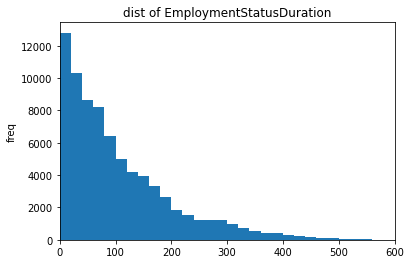

```python
pins = np.arange(0, interest_df.EmploymentStatusDuration.max()+20, 20)
plt.hist(interest_df.EmploymentStatusDuration, bins=pins);
plt.xlim((0,600))
plt.title('dist of EmploymentStatusDuration');
plt.ylabel('freq');
```

her the graph looks like a rational function where we find that as longer the employment is the lower number of people to take loans

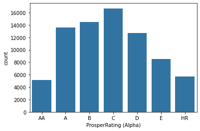

```python
order = ['AA', 'A', 'B', 'C', 'D', 'E', 'HR']
sns.countplot(x=interest_df['ProsperRating (Alpha)'], order = order, color=base_color);
```

more people tend to have a moderate level of risk with there investments or loans

> Make sure that, after every plot or related series of plots, that you include a Markdown cell with comments about what you observed, and what you plan on investigating next.

### Discuss the distribution(s) of your variable(s) of interest. Were there any unusual points? Did you need to perform any transformations?

> the prosper rating follows the normal distribution where more people tends to have a medium range of risk but the people who choose the high risk is more than the number who choose the low risk

### Of the features you investigated, were there any unusual distributions? Did you perform any operations on the data to tidy, adjust, or change the form of the data? If so, why did you do this?

> the BorrowerAPR has a strange distribution, and the dept to income ratio and the stated income follows the right skewed distribution. I set a limit to dept to income ratio and the monthly income and the duaration due to outliers

## Bivariate Exploration

> In this section, investigate relationships between pairs of variables in your data. Make sure the variables that you cover here have been introduced in some fashion in the previous section (univariate exploration).

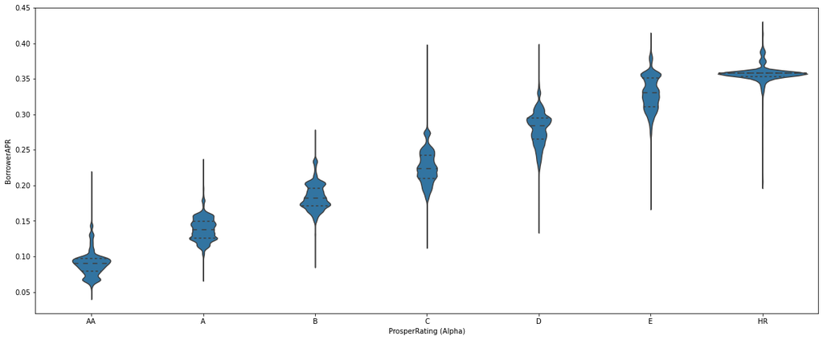

```python
plt.figure(figsize=(20,8))
sns.violinplot(data=interest_df, x='ProsperRating (Alpha)', y='BorrowerAPR', inner='quartile', color=base_color, order=order);
```

Here we see that as we go higher in prosper rating the APR becomes greater and more consentrated ending up at HR to be almost at 0.35 only we will investigate it more

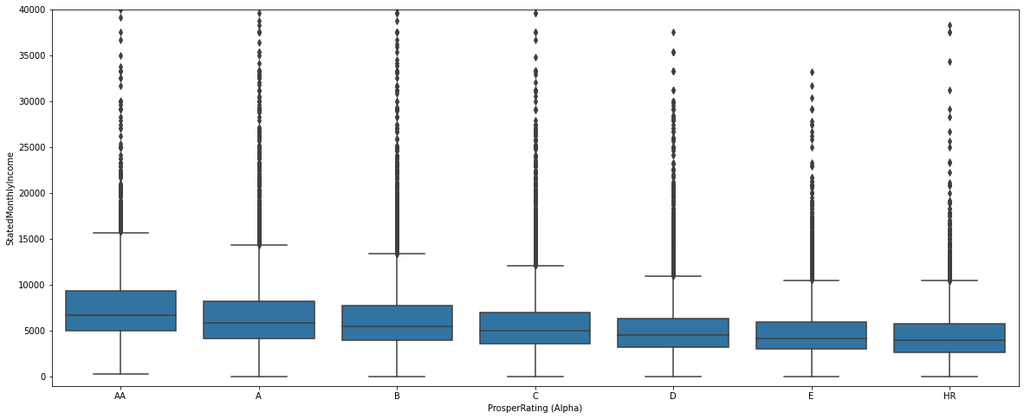

```python
plt.figure(figsize=(20,8))
sns.boxplot(data=interest_df, x='ProsperRating (Alpha)', y='StatedMonthlyIncome', color=base_color, order=order);
plt.ylim((-1000, 40000));
```

we can see here that the stated monthly doesn't have huge impact on the choosen plan but as we go higher in risk we see that there's more lower monthly income people choosing it.

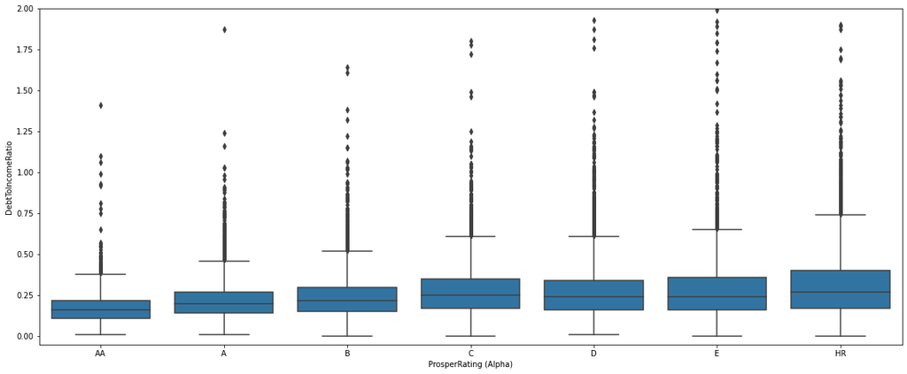

```python
plt.figure(figsize=(20,8))
sns.boxplot(data=interest_df, x='ProsperRating (Alpha)', y='DebtToIncomeRatio',
            color=base_color, order=order);
plt.ylim((-0.05, 2));
```

we see here that the dept to income ratio in median becomes higher as we get more risky prosper rating

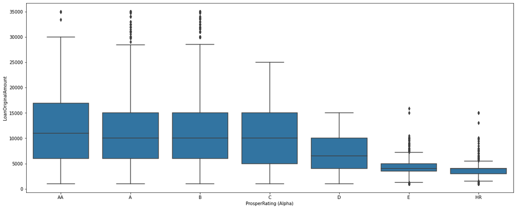

```python
plt.figure(figsize=(20,8))
sns.boxplot(data=interest_df, x='ProsperRating (Alpha)', y='LoanOriginalAmount',
            color=base_color, order=order);
```

same here we see that's just little change but the higher the risk the more the ratio of dept to income goes. and with the decrasing amount of loans we exepect the Borrowers to have a lower income range.

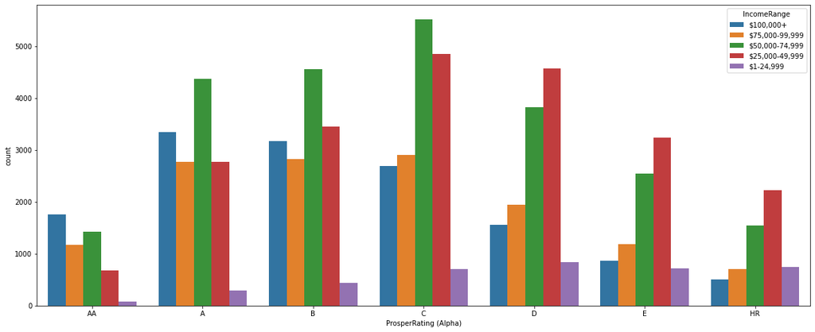

```python
plt.figure(figsize=(20,8))
order_income = ['$100,000+', '$75,000-99,999', '$50,000-74,999',
                '$25,000-49,999', '$1-24,999']
sns.countplot(data = interest_df, x = 'ProsperRating (Alpha)',
              hue = 'IncomeRange', order=order, hue_order=order_income)
```

we see here people with 100+K income tend to choose plan A and B, and from 75K-100K goes for A,B and C, 50-75K choose C more, and 25-50 tends to go for higher risks more to C and D, and 1-25K tends to choose higher risks and goes for C,D,E and HR with almost the same amount

```
(-0.05, 2.0)
```

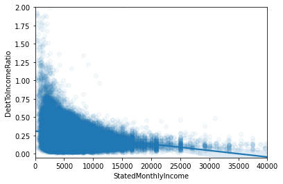

```python
sns.regplot(data=interest_df, y='DebtToIncomeRatio', x='StatedMonthlyIncome', scatter_kws={'alpha':0.05})
plt.xlim((0,40000))
plt.ylim((-0.05, 2))
```

here as the monthly indcome increases we get lower debt to income ratio

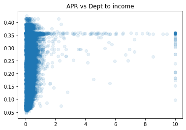

```python
plt.scatter(data=interest_df, y='BorrowerAPR', x='DebtToIncomeRatio', alpha=0.1);
plt.title('APR vs Dept to income')
```

here we have a strange values at 0.35 APR we'll investigate it more

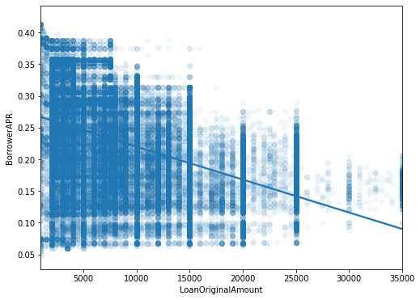

```python
plt.figure(figsize = [8, 6])
sns.regplot(data=interest_df, x = 'LoanOriginalAmount', y = 'BorrowerAPR', scatter_kws={'alpha':0.05});
```

as we go higher in loan original amount we get less APR

### Talk about some of the relationships you observed in this part of the investigation. How did the feature(s) of interest vary with other features in the dataset?

> we see as we go higher in the income the people tend to choose less risky plans.

## Multivariate Exploration

> Create plots of three or more variables to investigate your data even further. Make sure that your investigations are justified, and follow from your work in the previous sections.

```python
interest_df[interest_df.IncomeRange=='Not employed']
```

|  | ListingKey | EmploymentStatusDuration | BorrowerAPR | StatedMonthlyIncome | ProsperRating (Alpha) | Term | LoanOriginalAmount | DebtToIncomeRatio | TotalTrades | IncomeRange |
| --- | --- | --- | --- | --- | --- | --- | --- | --- | --- | --- |
| 21386 | BC0C3466047510716AB85FC | 38.0 | 0.288 | 2167.583333 | D | 36 | 1000 | 0.34 | 18.0 | Not employed |

```python
interest_df.drop(21386, inplace=True)
```

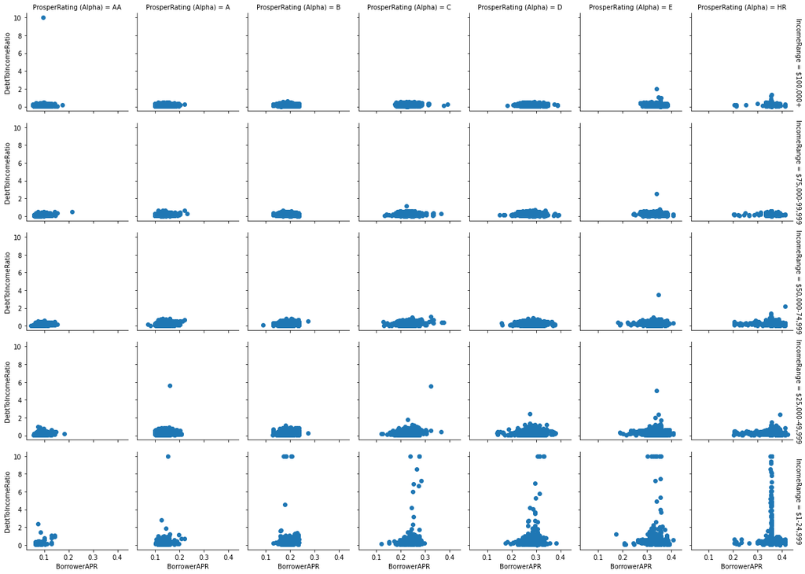

```python
g = sns.FacetGrid(data = interest_df, col = 'ProsperRating (Alpha)',
                  row = 'IncomeRange', height = 2.5, col_order=order,
                  margin_titles = True, row_order=order_income);
g.map(plt.scatter, 'BorrowerAPR', 'DebtToIncomeRatio');
```

here we see the big difference in how some people with salary range 1-25000 tend to choose a high dept to income ratio and for some reason it has big constration at 0.36 APR

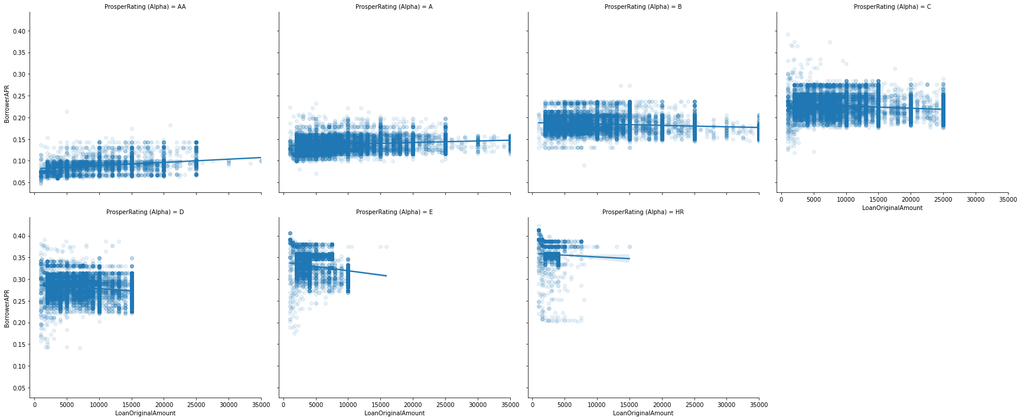

```python
g=sns.FacetGrid(data=interest_df, aspect=1.2, height=5,
                col='ProsperRating (Alpha)', col_wrap=4, col_order=order)
g.map(sns.regplot, 'LoanOriginalAmount', 'BorrowerAPR', x_jitter=0.04,
      scatter_kws={'alpha':0.1});
g.add_legend();
```

we see that APR tends to get lower as we increase the loan original amount in the more risky prosper ratings while the oppisite happens with less risky ones

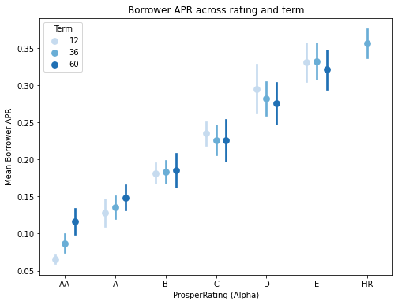

```python
fig = plt.figure(figsize = [8,6])
ax = sns.pointplot(data=interest_df, x='ProsperRating (Alpha)', y='BorrowerAPR',
                   hue='Term', order=order, palette = 'Blues', linestyles = '',
                   dodge = 0.4, ci='sd')
plt.title('Borrower APR across rating and term')
plt.ylabel('Mean Borrower APR')
ax.set_yticklabels([],minor = True);
```

we see that the lower APR the smaller the term in A and AA. and in B all thterms have the same APR while C,D and E has the oppisite of A and AA. finally we see only 36 month term in the HR

### Talk about some of the relationships you observed in this part of the investigation. Were there features that strengthened each other in terms of looking at your feature(s) of interest?

> we get the reason why there's a peak near 0.36 in the APR axis as more low income range people tend to make high risk

### Were there any interesting or surprising interactions between features?

> we find the annual percentage rate to be increasing in the A and AA prosper ratings and in other ratings the APR decrease with the loan amount increasing, we also find that that the term is increasing with the increase of APR in A and AA and all the same in B then as we go for more risky plans the less Term is preferable by the peaple with higher APR.